# ECON320-3 Assignment 1: James (Minkyu) Song

## Part I

- Objective: Basics of workspace and good practices: folders, working directories, clearing workspace, saving objects, saving outputs.*

1). Construct your personal code header to use for all scripts from thereon. A code header contains commented-out text that gives essential meta-information and uncommented code that sets up the working environment. For instance, code can be used to loading packages or setting up your working directory. Here is an example of a template:

```python
# Script name: james_song_assignment_01.ipynb
# Purpose of script: Assignment 1 of ECON320 with Dr.O'Connell
# Author: James (Minkyu) Song
# Date Created: September 4th 2022
# --------------------------
# Notes: NA
# ---------------------------
```

```python
import os

import matplotlib.pyplot as plt
import numpy as np
import pandas as pd
import seaborn as sns

# if needed:
# directory_path = r"C:\Users\Lenovo\Desktop\college_work\ECON320_lab\00_main_assignments"
# os.chdir(directory_path)

# darkmode only
sns.set_style("darkgrid", {"grid.linecolor": "white", "grid.linestyle": ":"})
plt.style.use('dark_background')
```

## Part II

- Objective: Perform steps in empirical economic analysis.*
- Reference: Wooldridge (7th edition), Chapter 1, Section 2*

1). Create an object "birthday" which is an integer formatted as "DDMMYYYY". For example, if your birthday is December 19 of 1990, then `birthday = 19121990`, use this object as your seed in the following two exercises.

```python
# feb 4th 1998
birthday = "04021998"
# set seed
rng = np.random.RandomState(int(birthday))
```

2). Write a script that flips a fair coin 10 times and generates a mean when heads = 1 and tails = 0. Then perform that process 1000 times, plot the distribution of those means, and report the mean of the means and the standard deviation of the means.

```python
def gen_mean_n_flip(birthday_string: str, rng: np.random.mtrand.RandomState, n: int) -> np.float64:
    cointoss = rng.choice(2, n) # takes n flips as input
    # 2 is the result (1 or 0) for cointoss
    # 10 is the amount of times this process is repeated.
    return np.mean(cointoss)

def gen_mean_1k_trials(birthday_string, rng, n) -> list:
    # list comprehension
    # mean of tossing coin toss trial (1 trial = cointoss 10 times) x 1000 saved as list
    thousand_means = [gen_mean_n_flip(birthday_string, rng, n) for _ in range(0,1000)]
    return thousand_means
```

```python
means_10x10000 = gen_mean_1k_trials(birthday, rng, 10)
```

```
With the seed set to my birthday,
And 10 flips each trial, repeated for 1000 times,
The Mean of the means is: 0.5006
The Standard Deviation of the means is: 0.15658748353556232

The distribution is plotted below:
```

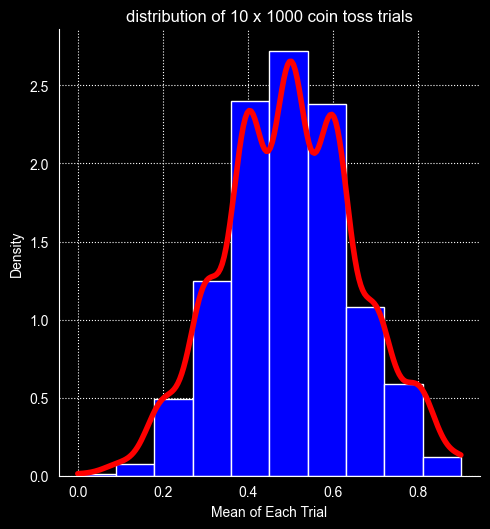

```python
mean_distribution_plot_10x1000 = sns.displot(
    data=means_10x10000,
    bins=10,
    stat="density",
    kde=True,
    color="red",
    line_kws={"lw": 4},
    facecolor="blue",
    edgecolor="white",
    kind="hist",
)

plt.xlabel("Mean of Each Trial")
plt.title("distribution of 10 x 1000 coin toss trials")
print("With the seed set to my birthday,")
print("And 10 flips each trial, repeated for 1000 times,")
print(f"The Mean of the means is: {np.mean(means_10x10000)}")
print(f"The Standard Deviation of the means is: {np.std(means_10x10000)}")
print("\nThe distribution is plotted below:")
plt.show()
```

3). Write a script that flips a fair coin 100 times and generates a mean, as above. Then perform that process 1000 times, plot the distribution of those means and report the mean of the means and the standard deviation of the means.

```
With the seed set to my birthday,
And 100 flips each trial, repeated for 1000 times,
The Mean of the means is: 0.49944
The Standard Deviation of the means is: 0.04850862191404741

The distribution is plotted below:
```

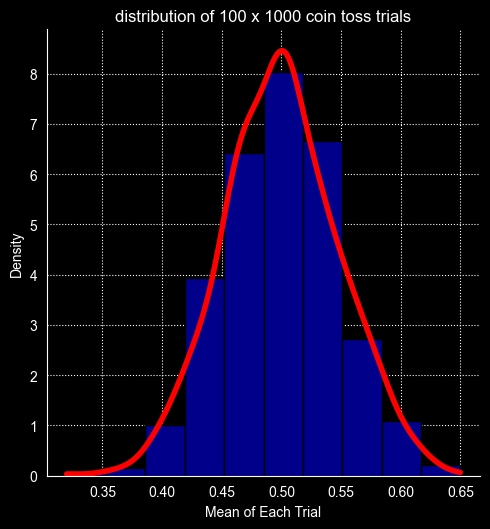

```python
means_100x10000 = gen_mean_1k_trials(birthday, rng, 100)
mean_distribution_plot_100x1000 = sns.displot(
    data=means_100x10000,
    bins=10,
    stat="density",
    kde=True,
    color="red",
    line_kws={"lw": 4},
    facecolor="darkblue",
    edgecolor="black",
    kind="hist",
)

plt.xlabel("Mean of Each Trial")
plt.title("distribution of 100 x 1000 coin toss trials")
print("With the seed set to my birthday,")
print("And 100 flips each trial, repeated for 1000 times,")
print(f"The Mean of the means is: {np.mean(means_100x10000)}")
print(f"The Standard Deviation of the means is: {np.std(means_100x10000)}")
print("\nThe distribution is plotted below:")
plt.show()
```

```python
# completed by: James (Minkyu) Song
# Student ID: 2235723
```